# course assignment Case 2 (Predicting Market to Book Ratio - MTB)

# It is necessary to first visualize whether variables have outliers before we can address them. I will use boxplots for visualization in order to do this. Variables that are greater than 1.5 times the upper quartile (75% of data) or lower than 1.5 times the lower quartile (25% of data) are regarded as outliers in boxplots, which identify outliers using the upper and lower bounds of their IQR. Hence, the IQR is the logical boundary of outliers for boxplots, which we use as our visualizers. We will be locating and handling any outliers of any of the variables in this dataset. However, we will only be recognizing and addressing the outliers of our independent variables when we create our model later on.

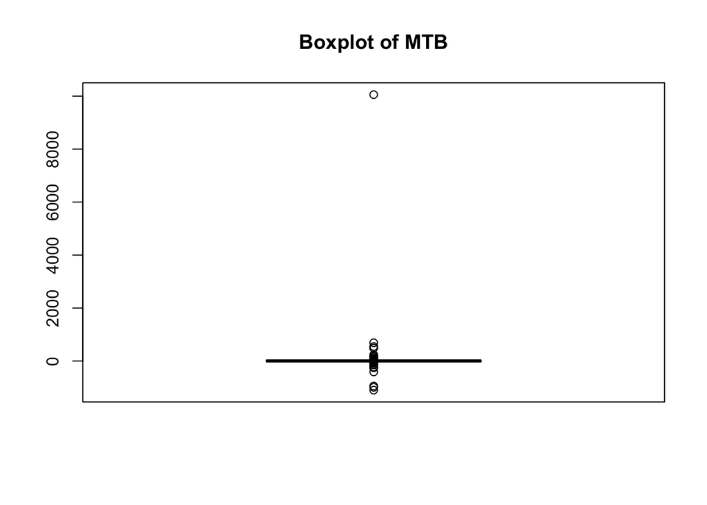

```r
boxplot(filtered_data1$MTB, main = "Boxplot of MTB", col = "hotpink")
```

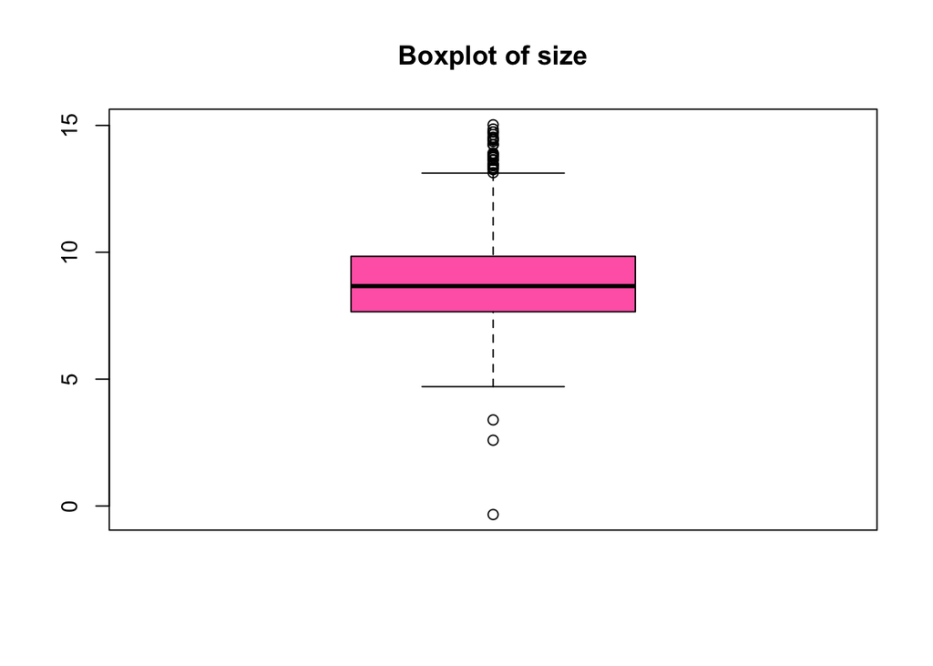

```r
boxplot(filtered_data1$size, main = "Boxplot of size", col = "hotpink")
```

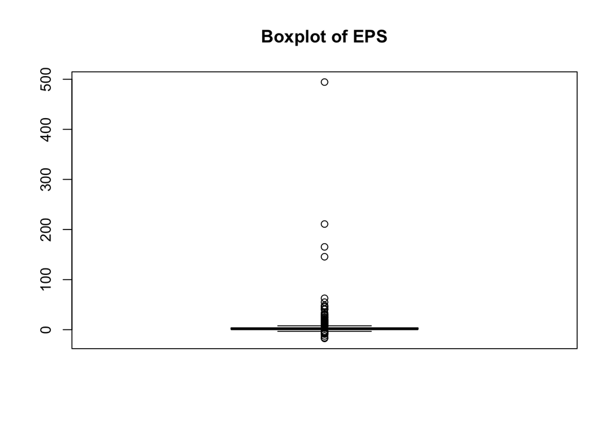

```r
boxplot(filtered_data1$EPS, main = "Boxplot of EPS", col = "hotpink")
```

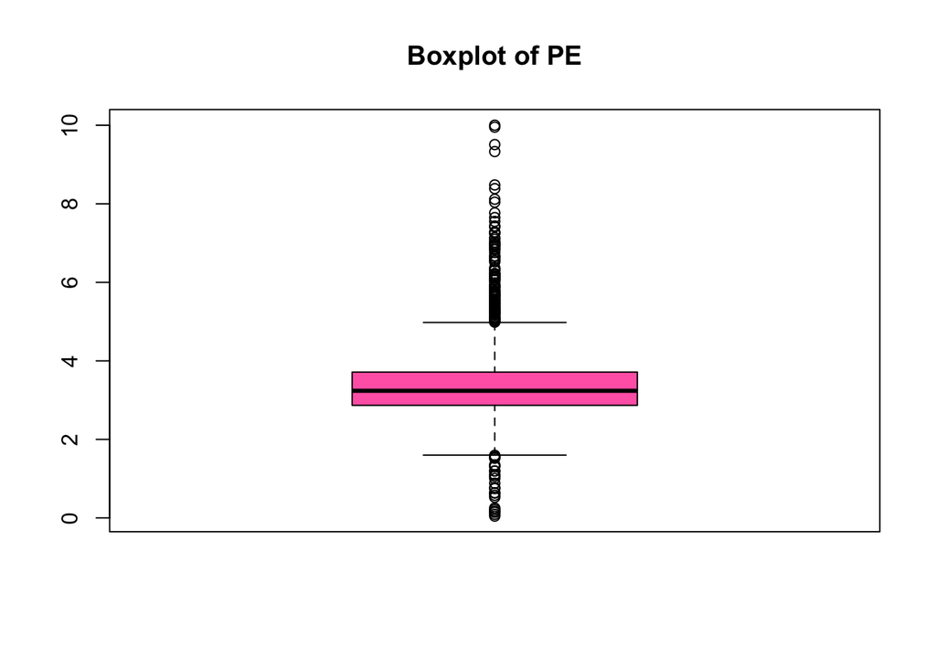

```r
boxplot(filtered_data1$PE, main = "Boxplot of PE", col = "hotpink")
```

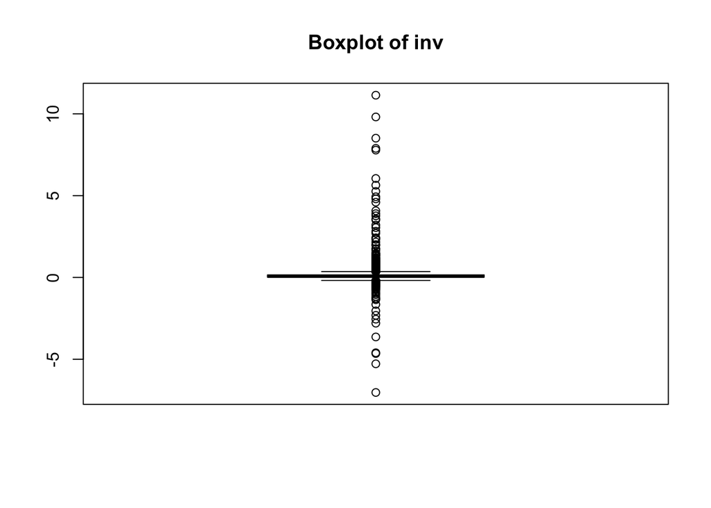

```r
boxplot(filtered_data1$inv, main = "Boxplot of inv", col = "hotpink")
```

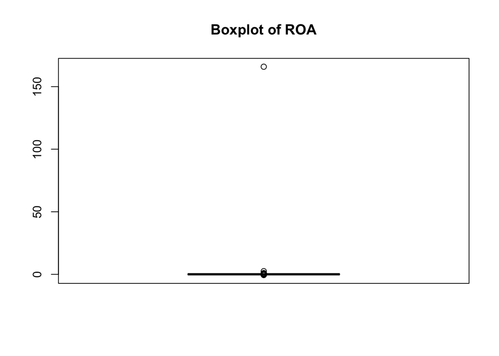

```r
boxplot(filtered_data1$ROA, main = "Boxplot of ROA", col = "hotpink")
```

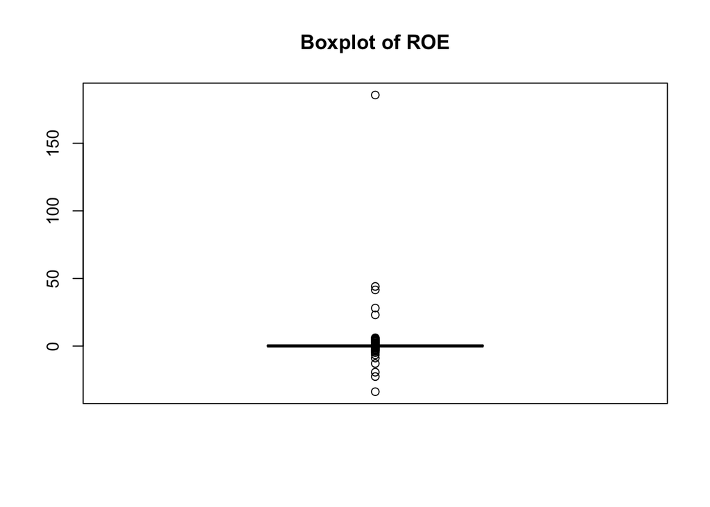

```r
boxplot(filtered_data1$ROE, main = "Boxplot of ROE", col = "hotpink")
```